# State Farm Distracted Drivers

```python
# dspLabels = ['A', 'B', 'C', 'D', 'E', 'F', 'G', 'H', 'I', 'J']

# print 'train set:'
# imgIxLst = np.random.random_integers(0, glbObsTrnFtr.shape[0] - 1, 10)
# for imgIx in imgIxLst:
#     print 'imgIx: %d: label: %s' % (imgIx, dspLabels[glbObsTrnRsp[imgIx]])
#     plt.figure
#     plt.imshow(glbObsTrnFtr[imgIx,:,:], cmap = plt.cm.gray)
#     plt.show()
```

```
New set:
  imgIx: 6018; id: img_14973.jpg; label: None
```

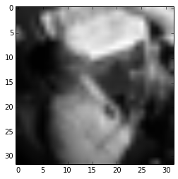

```
  imgIx: 54909; id: img_71431.jpg; label: None
```

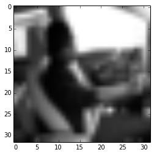

```
  imgIx: 17412; id: img_28095.jpg; label: None
```

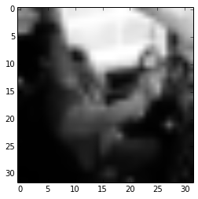

```
  imgIx: 66441; id: img_84692.jpg; label: None
```

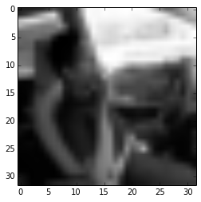

```
  imgIx: 29698; id: img_42352.jpg; label: None
```

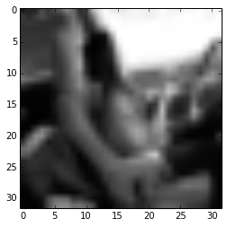

```
  imgIx: 21633; id: img_33020.jpg; label: None
```

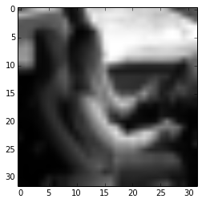

```
  imgIx: 67069; id: img_85415.jpg; label: None
```

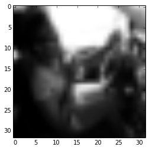

```
  imgIx: 46206; id: img_61395.jpg; label: None
```

[figure not shown]

```
  imgIx: 55126; id: img_71687.jpg; label: None
```

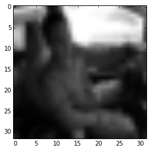

```
  imgIx: 53542; id: img_69827.jpg; label: None
```

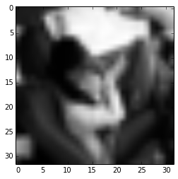

[output not shown]

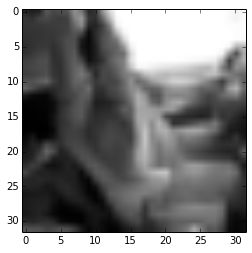

[output not shown]

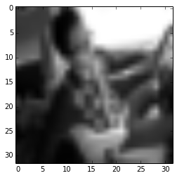

[output not shown]

[8 more figures not shown]

```python
print 'New set:'; mydisplayImages(glbObsNewIdn, glbObsNewFtr, glbObsNewRsp)
```

### Shuffle data

Next, we'll randomize the data. It's important to have the labels well shuffled for the training and test distributions to match.

```python
# print type(glbObsTrnIdn)
# smpObsTrnIdn = glbObsTrnIdn[0:4]
# print smpObsTrnIdn
# print [smpObsTrnIdn[ix] for ix in [3, 1, 2, 0]]
# smpObsTrnIdn = [smpObsTrnIdn[ix] for ix in [3, 1, 2, 0]]
# print smpObsTrnIdn
```

[output not shown]

```python
np.random.seed(glbObsShuffleSeed)
def randomize(ids, dataset, labels):
  permutation = np.random.permutation(labels.shape[0])
  shuffled_ids = [ids[ix] for ix in permutation]
  shuffled_dataset = dataset[permutation,:,:]
  shuffled_labels = labels[permutation]
  return shuffled_ids, shuffled_dataset, shuffled_labels

glbObsTrnIdn, glbObsTrnFtr, glbObsTrnRsp = randomize(glbObsTrnIdn, glbObsTrnFtr, glbObsTrnRsp)
#glbObsNewIdn, glbObsNewFtr, glbObsNewRsp = randomize(glbObsNewIdn, glbObsNewFtr, glbObsNewRsp)
```

```python
# np.random.seed(133)
# def randomize(dataset, labels):
#   permutation = np.random.permutation(labels.shape[0])
#   shuffled_dataset = dataset[permutation,:,:]
#   shuffled_labels = labels[permutation]
#   return shuffled_dataset, shuffled_labels
# glbObsTrnFtr, glbObsTrnRsp = randomize(glbObsTrnFtr, glbObsTrnRsp)
# glbObsNewFtr, glbObsNewRsp = randomize(glbObsNewFtr, glbObsNewRsp)
```

Check if data is still good after shuffling!

```
shuffled Trn set:
  imgIx: 16454; id: img_64535.jpg; label: c2
```

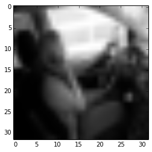

```
  imgIx: 7390; id: img_17025.jpg; label: c2
```

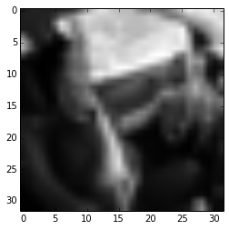

```
  imgIx: 8078; id: img_86976.jpg; label: c0
```

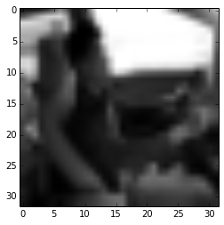

```
  imgIx: 21232; id: img_6938.jpg; label: c2
```

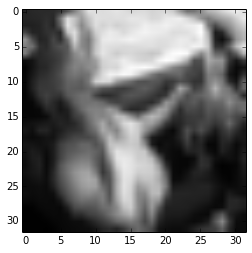

```
  imgIx: 15937; id: img_51095.jpg; label: c9
```

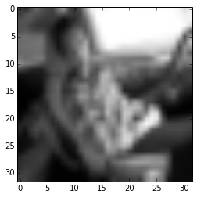

```
  imgIx: 6158; id: img_21315.jpg; label: c7
```

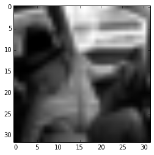

```
  imgIx: 940; id: img_12231.jpg; label: c8
```

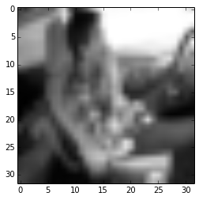

```
  imgIx: 5581; id: img_40944.jpg; label: c0
```

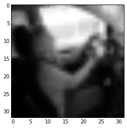

```
  imgIx: 247; id: img_46103.jpg; label: c2
```

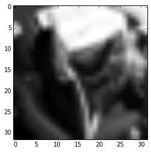

```
  imgIx: 15779; id: img_65559.jpg; label: c0
```

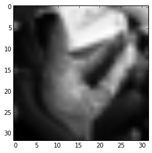

[output not shown]

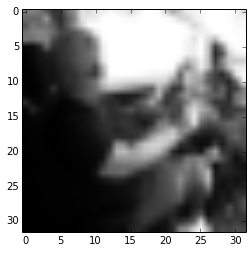

[output not shown]

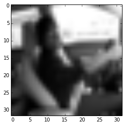

[output not shown]

[8 more figures not shown]

```python
print 'shuffled Trn set:'; mydisplayImages(glbObsTrnIdn, glbObsTrnFtr, glbObsTrnRsp)
#print 'shuffled New set:'; mydisplayImages(glbObsNewIdn, glbObsNewFtr, glbObsNewRsp)
```

Prune the training data as needed. Depending on your computer setup, you might not be able to fit it all in memory, and you can tune obsTrnN as needed.

Also create a validation dataset for hyperparameter tuning.

```python
obsTrnN = glbObsTrnFtr.shape[0] # or fixed number e.g. 20000
obsVldN = int(obsTrnN * 0.2)
print 'obsTrnN: %d; obsVldN: %d' % (obsTrnN, obsVldN)

glbObsVldIdn = glbObsTrnIdn[:obsVldN]
glbObsVldFtr = glbObsTrnFtr[:obsVldN,:,:]
glbObsVldRsp = glbObsTrnRsp[:obsVldN]

glbObsFitIdn = glbObsTrnIdn[obsVldN:obsVldN+obsTrnN]
glbObsFitFtr = glbObsTrnFtr[obsVldN:obsVldN+obsTrnN,:,:]
glbObsFitRsp = glbObsTrnRsp[obsVldN:obsVldN+obsTrnN]

print('   Fitting:', len(glbObsFitIdn), glbObsFitFtr.shape, glbObsFitRsp.shape)
print('Validation:', len(glbObsVldIdn), glbObsVldFtr.shape, glbObsVldRsp.shape)
```

```
obsTrnN: 22424; obsVldN: 4484
('   Fitting:', 17940, (17940, 32, 32), (17940,))
('Validation:', 4484, (4484, 32, 32), (4484,))
```

```python
# obsTrnN = glbObsTrnFtr.shape[0]
# #obsTrnN = 200000
# obsVldN = 10000

# glbObsVldFtr = glbObsTrnFtr[:obsVldN,:,:]
# glbObsVldRsp = glbObsTrnRsp[:obsVldN]
# glbObsTrnFtr = glbObsTrnFtr[obsVldN:obsVldN+obsTrnN,:,:]
# glbObsTrnRsp = glbObsTrnRsp[obsVldN:obsVldN+obsTrnN]
# print('Training', glbObsTrnFtr.shape, glbObsTrnRsp.shape)
# print('Validation', glbObsVldFtr.shape, glbObsVldRsp.shape)
```

Finally, let's save the data for later reuse:  
Remember to save previous pickled file as '_unshuffled'

```python
# glbPickleFile = os.getcwd() + '/data/notMNIST.pickle'
# print glbPickleFile
```

```python
try:
  f = open('data/' + glbPickleFile, 'wb')
  save = {
    'glbObsTrnIdn': glbObsTrnIdn,
    'glbObsTrnFtr': glbObsTrnFtr,
    'glbObsTrnRsp': glbObsTrnRsp,

    'glbObsFitIdn': glbObsFitIdn,
    'glbObsFitFtr': glbObsFitFtr,
    'glbObsFitRsp': glbObsFitRsp,

    'glbObsVldIdn': glbObsVldIdn,
    'glbObsVldFtr': glbObsVldFtr,
    'glbObsVldRsp': glbObsVldRsp,

    'glbObsNewIdn': glbObsNewIdn,
    'glbObsNewFtr': glbObsNewFtr,
    'glbObsNewRsp': glbObsNewRsp,
    }
  pickle.dump(save, f, pickle.HIGHEST_PROTOCOL)
  f.close()
except Exception as e:
  print('Unable to save data to', glbPickleFile, ':', e)
  raise

statinfo = os.stat('data/' + glbPickleFile)
print('Compressed pickle size:', statinfo.st_size)
```

```
('Compressed pickle size:', 512899134)
```

```python
# #glbPickleFile = 'notMNIST.pickle'

# try:
#   f = open(glbPickleFile, 'wb')
#   save = {
#     'glbObsTrnFtr': glbObsTrnFtr,
#     'glbObsTrnRsp': glbObsTrnRsp,
#     'glbObsVldFtr': glbObsVldFtr,
#     'glbObsVldRsp': glbObsVldRsp,
#     'glbObsNewFtr': glbObsNewFtr,
#     'glbObsNewRsp': glbObsNewRsp,
#     }
#   pickle.dump(save, f, pickle.HIGHEST_PROTOCOL)
#   f.close()
# except Exception as e:
#   print('Unable to save data to', glbPickleFile, ':', e)
#   raise
```

## Inspect overlap

By construction, this dataset might contain a lot of overlapping samples, including training data that's also contained in the validation and test set! Overlap between training and test can skew the results if you expect to use your model in an environment where there is never an overlap, but are actually ok if you expect to see training samples recur when you use it. Measure how much overlap there is between training, validation and test samples.

Optional questions:

- What about near duplicates between datasets? (images that are almost identical)
- Create a sanitized validation and test set, and compare your accuracy on those in subsequent assignments.

```python
# print glbObsTrnFtr[0:3]
# print np.ascontiguousarray(glbObsTrnFtr[0:3])
# print np.ascontiguousarray(glbObsTrnFtr[0:3]).shape
```

```python
obsFitSet = set(img.tostring() for img in glbObsFitFtr)
print 'Fit: shape: %s vs. len(set): %d pctDups: %0.4f' % \
    (glbObsFitFtr.shape, len(obsFitSet), \
     (glbObsFitFtr.shape[0] * 1.0 / len(obsFitSet) - 1) * 100)

obsVldSet = set(img.tostring() for img in glbObsVldFtr)
print 'Vld: shape: %s vs. len(set): %d pctDups: %0.4f' % \
    (glbObsVldFtr.shape, len(obsVldSet), \
     (glbObsVldFtr.shape[0] * 1.0 / len(obsVldSet) - 1) * 100)

obsNewSet = set(img.tostring() for img in glbObsNewFtr)
print 'New: shape: %s vs. len(set): %d pctDups: %0.4f' % \
    (glbObsNewFtr.shape, len(obsNewSet), \
     (glbObsNewFtr.shape[0] * 1.0 / len(obsNewSet) - 1) * 100)
```

```
Fit: shape: (17940, 32, 32) vs. len(set): 17940 pctDups: 0.0000
Vld: shape: (4484, 32, 32) vs. len(set): 4484 pctDups: 0.0000
New: shape: (79726, 32, 32) vs. len(set): 79724 pctDups: 0.0025
```

```python
#print glbObsTrnFtr[0:3]
# obsFitSet = set(img.tostring() for img in glbObsTrnFtr)
# print 'train: shape: %s vs. len(set): %d pctDups: %0.4f' % \
#     (glbObsTrnFtr.shape, len(obsFitSet), \
#      (glbObsTrnFtr.shape[0] * 1.0 / len(obsFitSet) - 1) * 100)

# validSet = set(img.tostring() for img in glbObsVldFtr)
# print 'valid: shape: %s vs. len(set): %d pctDups: %0.4f' % \
#     (glbObsVldFtr.shape, len(validSet), \
#      (glbObsVldFtr.shape[0] * 1.0 / len(validSet) - 1) * 100)

# obsNewSet = set(img.tostring() for img in glbObsNewFtr)
# print 'test : shape: %s vs. len(set): %d pctDups: %0.4f' % \
#     (glbObsNewFtr.shape, len(obsNewSet), \
#      (glbObsNewFtr.shape[0] * 1.0 / len(obsNewSet) - 1) * 100)
```

```python
print 'Vld set overlap with Fit set: %0.4f' % \
    (len(obsVldSet.intersection(obsFitSet)) * 1.0 / len(obsVldSet))
print 'Vld set overlap with New set: %0.4f' % \
    (len(obsVldSet.intersection(obsNewSet)) * 1.0 / len(obsNewSet))
print 'Fit set overlap with New set: %0.4f' % \
    (len(obsFitSet.intersection(obsNewSet)) * 1.0 / len(obsFitSet))
# print ' test set overlap with train set: %0.4f' % \
#     (len( obsNewSet.intersection(obsFitSet)) * 1.0 / len( obsNewSet))
# print 'valid set overlap with  test set: %0.4f' % \
#     (len(validSet.intersection( obsNewSet)) * 1.0 / len(validSet))
```

```
Vld set overlap with Fit set: 0.0000
Vld set overlap with New set: 0.0000
Fit set overlap with New set: 0.0000
```

## Stop here!

Following code is in img_02_fit_lgtRgr_SFDD

Let's get an idea of what an off-the-shelf classifier can give you on this data. It's always good to check that there is something to learn, and that it's a problem that is not so trivial that a canned solution solves it.

Train a simple model on this data using 50, 100, 1000 and 5000 training samples. Hint: you can use the LogisticRegression model from sklearn.linear_model.

Optional question: train an off-the-shelf model on all the data!

```python
# import graphlab
# print graphlab.version
# graphlab.canvas.set_target('ipynb')
```

[output not shown]

```python
# graphlab.logistic_classifier.create(image_train,target='label',
#                                               features=['image_array'])
```

```python
print glbObsTrnFtr[0:3,:,:]
print np.reshape(glbObsTrnFtr[0:3,:,:], (3, glbObsTrnFtr.shape[1] * glbObsTrnFtr.shape[2]))
print np.reshape(glbObsTrnFtr[0:3,:,:], (3, glbObsTrnFtr.shape[1] * glbObsTrnFtr.shape[2])).shape
```

[output not shown]

```python
from sklearn import metrics, linear_model
import pandas as pd
```

```python
def fitMdl(nFitObs = 50):
    mdl = linear_model.LogisticRegression(verbose = 1)
    mdl.fit(np.reshape(glbObsTrnFtr[0:nFitObs,:,:], \
                            (nFitObs, glbObsTrnFtr.shape[1] * glbObsTrnFtr.shape[2])), \
                 glbObsTrnRsp[0:nFitObs])
    print mdl.get_params()
    print mdl.coef_.shape
    print '  coeff stats:'
    for lblIx in xrange(len(dspLabels)):
        print '  label:%s; minCoeff:row:%2d, col:%2d, value:%0.4f; maxCoeff:row:%2d, col:%2d, value:%0.4f;' % \
            (dspLabels[lblIx], \
             mdl.coef_[lblIx,:].argmin() / glbImgSz, \
             mdl.coef_[lblIx,:].argmin() % glbImgSz, \
             mdl.coef_[lblIx,:].min(), \
             mdl.coef_[lblIx,:].argmax() / glbImgSz, \
             mdl.coef_[lblIx,:].argmax() % glbImgSz, \
             mdl.coef_[lblIx,:].max())

    train_pred_labels = mdl.predict(np.reshape(glbObsTrnFtr[0:nFitObs,:,:], \
                                                    (nFitObs               , glbImgSz ** 2)))
    accuracy_train = metrics.accuracy_score(train_pred_labels, glbObsTrnRsp[0:nFitObs])
    print '  accuracy train:%0.4f' % (accuracy_train)
    print metrics.confusion_matrix(glbObsTrnRsp[0:nFitObs], train_pred_labels)

    valid_pred_labels = mdl.predict(np.reshape(glbObsVldFtr, \
                                                    (glbObsVldFtr.shape[0], glbImgSz ** 2)))
    accuracy_valid = metrics.accuracy_score(valid_pred_labels, glbObsVldRsp)
    print '  accuracy valid:%0.4f' % (accuracy_valid)
    print metrics.confusion_matrix(glbObsVldRsp           , valid_pred_labels)

    test_pred_labels  = mdl.predict(np.reshape(glbObsNewFtr, \
                                                    (glbObsNewFtr.shape[0], glbImgSz ** 2)))
    accuracy_test = metrics.accuracy_score( test_pred_labels,  glbObsNewRsp)
    print '  accuracy  test:%0.4f' % (accuracy_test)
    test_conf = pd.DataFrame(metrics.confusion_matrix( glbObsNewRsp,  test_pred_labels), \
                             index = dspLabels, columns = dspLabels)
    print test_conf

    return(mdl, (accuracy_train, accuracy_valid, accuracy_test))
```

```python
mdl50 = fitMdl(nFitObs = 50)
```

[output not shown]

```python
models = pd.DataFrame({'nFitObs': [1e2, 1e3, 1e4, 1e5, glbObsTrnFtr.shape[0]]})
models = models.set_index(models['nFitObs'])
models['mdl'] = linear_model.LogisticRegression()
models['accuracy.fit'] = -1; models['accuracy.vld'] = -1; models['accuracy.new'] = -1

for thsN in models['nFitObs']:
    models.ix[thsN, 'mdl'], (models.ix[thsN, 'accuracy.fit'], \
                             models.ix[thsN, 'accuracy.vld'], \
                             models.ix[thsN, 'accuracy.new'], \
                            ) = fitMdl(nFitObs = thsN)

print models
```

```
[LibLinear]{'warm_start': False, 'C': 1.0, 'n_jobs': 1, 'verbose': 1, 'intercept_scaling': 1, 'fit_intercept': True, 'max_iter': 100, 'penalty': 'l2', 'multi_class': 'ovr', 'random_state': None, 'dual': False, 'tol': 0.0001, 'solver': 'liblinear', 'class_weight': None}
```

[output not shown]

[output cut: 194 more lines]

[output not shown]

[figure not shown]

```python
plt.figure()
plt.plot(models['nFitObs'], models['accuracy.fit'], 'bo-', label = 'fit')
plt.plot(models['nFitObs'], models['accuracy.vld'], 'rs-', label = 'vld')
plt.plot(models['nFitObs'], models['accuracy.new'], 'gp-', label = 'new')
plt.legend()
plt.title("Accuracy")
plt.xscale('log')
axes = plt.gca()
axes.set_xlabel('nFitObs')
# axes.set_xlim([mdlDF['l1_penalty'][mdlDF['RSS.vld'].argmin()] / 10 ** 2, \
#                mdlDF['l1_penalty'][mdlDF['RSS.vld'].argmin()] * 10 ** 2])
# axes.set_ylim([0, mdlDF['RSS.vld'].min() * 1.5])
plt.show()
```

```python
print dspLabels
```

```
['A', 'B', 'C', 'D', 'E', 'F', 'G', 'H', 'I', 'J']
```

```python
import pandas as pd
```

[output not shown]